# COGS 118A- Project Proposal

# Binary Classification: Diabetes Prediction

# Names

- Connor McManigal
- Donggyu(Alex) Yu
- Jungwoo(Kevin) Park
- Shivani Suthar

# Abstract

This project aims to solve the difficulty associated with making accurate diagnoses of diabetes in patients. If a patient is incorrectly diagnosed, it could lead to dire consequences, such as additional health issues or even death. Our goal is to solve this problem by designing machine learning algorithms that will accurately predict whether a patient has diabetes. Our data encompasses eight features such as age, gender, body mass index(BMI), hypertension, heart disease, smoking history, HbA1c levels, and blood glucose levels, along with their diabetes status: positive or negative. These electronic health records are collected through surveys, medical records, and laboratory tests from individuals by healthcare providers in hospitals or clinics. With this data, we will train multiple binary classification algorithms and select the algorithm that provides the highest sensitivity. We will compare the performances of logistic regression, decision tree, k-nearest neighbor, and support vector machines to see which algorithm best suits our needs. We will measure performance using sensitivity, precision, specificity, ROC-AUC, and precision-recall curves with a heavy emphasis on high recall, as it is important to detect all the positive diabetes cases in order to provide immediate treatment.

# Background

Health-related issues have significant impacts on the lives of countless individuals and families worldwide. Among these issues, diabetes has emerged as a disease that is incurable and can only be treated. According to the World Health Organization (WHO), about 422 million people across the world are suffering from diabetes and the majority of them come from low or middle income countries. More devastatingly, about 1.5 million individuals face death because of diabetes<sup>[1]</sup>. When diabetes goes untreated, it could also result in other medical issues such as heart disease or stroke. Despite the availability of improved medical treatments, the true extent of diabetes often remains concealed in our daily lives. While medicinal advancements have improved diabetes treatment, there is still no cure and this leaves many individuals and families struggling with the long-term consequences. The insidious nature of diabetes further complicates its identification and detection. Another fact about diabetes is that there are two different types: type I and type II. The significant difference between type one and type two diabetes is that type one diabetes shows during adolescence and is genetically inherited; in which the pancreas does not make insulin at all. On the other hand, type two diabetes patients' experience less insulin production and it develops throughout life, typically showing up in adulthood. This makes it especially difficult to diagnose diabetes because both genetic and environmental components such as diet or exercise can be involved.<sup>[2]</sup> Additionally, the symptoms of diabetes often overlap with those of other diseases, making early detection challenging. Common early signs of diabetes include fatigue and extreme hunger <sup>[3]</sup>. However, due to their subtle nature and resemblance to symptoms of other diseases, they frequently go unnoticed or are misattributed, making it hard for timely diagnosis.

# Problem Statement

People suffer from diabetes when their body fails to produce enough insulin or cannot properly use insulin to turn glucose into energy. This typically results in high blood glucose levels and this dramatically increases the risk of heart diseases, stroke, kidney diseases, eye problems, dental diseases, nerve damage, and even foot problems. Other symptoms can include frequent urination, fatigue, slow healing, extreme thirst, and weight loss. These warning signs can easily be overlooked and often overlap with other minor health problems. Some accurate medical indicators for evaluating susceptibility for diabetes include body mass index (BMI), hypertension, heart disease, smoking history, HbA1c levels, and blood glucose levels. Despite diabetes' serious nature, early detection followed by change of habits and proper medications can significantly lower the risk of serious diseases. We plan to solve this problem by classifying patients with diabetes based on their medical records in conjunction with some of their demographic information through multiple ML-algorithms: decision trees, k-nearest neighbors, logistic regressions, and support vector machines. This problem is quantifiable as a binary classification; positive class means that the patient has diabetes and negative class depicts that the patient does not have diabetes. Our metrics for evaluating the performance of these algorithms will include sensitivity, precision, specificity, ROC-AUC, and precision-recall curve with heavy emphasis on high sensitivity, as it is important to detect patients who have diabetes in order for them to receive immediate treatment. This problem is highly replicable because diabetes is found across the globe and it commonly has different precursors depending on individual health differences. We think that there could be additional features that would help us properly label patients with diabetes such as additional demographic information, how regularly someone exercises, and what their diet consists of. Through our implementation of various machine learning techniques, we believe we can train successful models that will predict patients with diabetes from data containing new individuals.

# Data

We have located a diabetes dataset from kaggle that includes 7 numerical variables, 2 categorical variables, and 100,000 observations. Amongst the 7 numeric variables, we have the patients’ age, body mass index(BMI), HbA1c level, blood glucose level, and binaries describing whether or not they had hypertension, heart disease, or diabetes. Our two categorical variables include the patient’s gender with 3 unique categories (male/female/other) and smoking history with six unique categories (never/no info/current/former/ever/not current). We feel that this is an adequate amount of observations and variables to utilize machine learning to perform this binary classification task.

- Link: https://www.kaggle.com/datasets/iammustafatz/diabetes-prediction-dataset
- Dataset size: 100,000 x 9 = 100,000 observations and 9 variables(8 when not including our diabetes truth label)
- A single observation consists of a single “patient” and each row contains a pateints’ respective age, body mass index(BMI), HbA1c level, blood glucose level, gender, smoking history, as well as hypertension, heart disease, and diabetes information(denoted as 0’s or 1’s).
- We think that all the variables besides the diabetes binary will be integral when training. We think that an individual’s age, BMI, HbA1c level, blood glucose level, smoking history, gender, and hypertension as well as heart disease information will all contribute close to equal value to our predictive accuracy. The ninth variable, or the ‘diabetes’ variable will serve as our truth label within the data. After conducting a rough exploratory data analysis on the data, we found that 8.5% of the 100,000 individuals within the data contain diabetes of some sort(either diabetes I or II). Interestingly, this sample has a similar diabetes rate to the US, which is roughly 11.3% of the population.
- Also, this data set is extremely tidy and contains no missing values. We used the skimr R package to analyze our variables’ missingness, distinct values, and for numerics, maximum and minimum values. With that being said, two variables and their distinct values stood out to us most: age and smoking history. The age variable, represented as a numeric, contains values from 0.08 to 80.0. This means that the data contains patients from roughly 1 month old to 80 years old. As of now, we will leave this variable be, but we may end up narrowing down our analysis to a specific age group. In respect to smoking history, there are 6 unique categories and they include never, no info, current, former, ever, and not current. On kaggle there isn’t a data dictionary listed, so we weren’t sure what the difference was between some of the categories(i.e. “not current” versus “former”), however, we found better descriptions under the discussion section. We will most likely leave this feature as is.

# Proposed Solution

Since we want to correctly classify diabetes and not allow those with diabetes to be misclassified, we desire a high true positive rate and a low false negative rate for our binary classification. In order to do this, we will utilize an individual’s features such as age, gender, body mass index(BMI), hypertension, heart disease, smoking history, HbA1c levels, and blood glucose levels. To start, it is necessary that our data is ready for proper implementation in our algorithms and this means we will have to standardize the data by z-scoring or using scalars on the data(i.e. ‘age’ ranges from 0.08 to 80 which is a relatively large gap). In addition, we will also one-hot encode our categorical features(i.e. ‘gender’ and ‘smoking history’). Since the data already has true labeled values, and the labels are imbalance, we will use make_imbalance from imblearn (one of sklearn package).

We will seek to find the best performing algorithm by utilizing cross-validation on our hyperparameters. Since our number of observations is large(100,000 rows), we will most likely not be able to use Grid Search. We should note that Grid Search would be ideal in this situation, however, it is typically not feasible on large amounts of data. So, if our implementation of Grid Search fails, we plan to use Random Search to tune for the best hyperparameters for each of our algorithms: logistic regression, k-nearest neighbor, support vector machine, and decision tree. After finding the best hyperparameters for each algorithm, we will be able to compare each algorithm’s accuracy scores. We will also consider evaluation metrics. More specifically, we do not want our models to falsely classify diabetes and we desire our models to minimize the number of false negatives(falsely classifying as negative could result in a patient going untreated). So we will take a look at each algorithm's sensitivity, false negative rate, and visually analyze the ROC-AUC curves to compare and contrast algorithms. Note that we want our models to provide high sensitivity or recall, all while maintaining low false negative rates.

To implement each algorithm, we will first need to perform a train-test split on the data. We will use Sklearn libraries to split our data into training and testing, and use those separated datasets according to each algorithm. The Grid search(or Random search) will have a k value as an argument which will split the train and hold out sets to carry out fit and test errors. So we will use k=5 across all Grid Searches (or Random Searches). We do not need to go through feature selection (PCA) because we are pretty limited on our variables and the variables that we do have are extremely relevant for making diabetes diagnoses.

We found a similar benchmark in line with our approach which showed 96.99% accuracy using ANN(Artificial Neural Network), however, this benchmark did not tune the hyperparameters. Despite this, we think this benchmark could serve as a good comparison after we tune the hyperparameters using Grid or Random search <sup>[6]</sup>.

# Evaluation Metrics

For our specific binary diabetes classification problem, we want our algorithm(s) to accurately classify the true positives within the data while minimizing the number of false negatives. Specifically, we want our algorithm(s) to provide a high sensitivity or recall (TP/TP + FN) and maintain a low false negative rate (FNR = 1 - TPR). The reason for this is because we don’t want our algorithm to falsely classify a patient as not having diabetes, when in reality they do. The worst case scenario is if our algorithm falsely classifies a patient as negative, when in fact they are positive. When someone gets diagnosed with diabetes, they require immediate treatment and medical attention, so it is essential that we catch all of the true positives. We will also use confusion matrices, ROC-AUC curvesto visually inspect our algorithms’ predictive accuracy and results. In regard to ROC-AUC, we want to minimize the false positives and false negatives while making sure to pick up on as many of the true positives and true negatives that we can. Also, we are going to want to maximize the area under the curve(AUC). Finally, we will analyze our algorithms’ specificity(TN/TN + FP) and precision(TP/TP + FP).

# Exploratory Data Analysis

```python
# importing packages for visualization and data manipulation
import numpy as np
import matplotlib.pyplot as plt
import pandas as pd
import seaborn as sns
import joblib
import warnings
```

```python
df = pd.read_csv("diabetes_prediction_dataset.csv")
```

```python
df.head()
```

|  | gender | age | hypertension | heart_disease | smoking_history | bmi | HbA1c_level | blood_glucose_level | diabetes |
| --- | --- | --- | --- | --- | --- | --- | --- | --- | --- |
| 0 | Female | 80.0 | 0 | 1 | never | 25.19 | 6.6 | 140 | 0 |
| 1 | Female | 54.0 | 0 | 0 | No Info | 27.32 | 6.6 | 80 | 0 |
| 2 | Male | 28.0 | 0 | 0 | never | 27.32 | 5.7 | 158 | 0 |
| 3 | Female | 36.0 | 0 | 0 | current | 23.45 | 5.0 | 155 | 0 |
| 4 | Male | 76.0 | 1 | 1 | current | 20.14 | 4.8 | 155 | 0 |

### Check and drop duplicated observations

```python
duo_rows = df[df.duplicated()]
print("Rows to remove:", duo_rows.shape)
```

```
Rows to remove: (3854, 9)
```

```python
df = df.drop_duplicates()
df.shape
```

```
(96146, 9)
```

### Explore Datasets

```python
df.dtypes
```

```
gender                  object
age                    float64
hypertension             int64
heart_disease            int64
smoking_history         object
bmi                    float64
HbA1c_level            float64
blood_glucose_level      int64
diabetes                 int64
dtype: object
```

```python
df['smoking_history'].value_counts()
```

```
never          34398
No Info        32887
former          9299
current         9197
not current     6367
ever            3998
Name: smoking_history, dtype: int64
```

```python
df['gender'].value_counts()
```

```
Female    56161
Male      39967
Other        18
Name: gender, dtype: int64
```

#### Check for missing observations

```python
df.isnull().sum()
```

```
gender                 0
age                    0
hypertension           0
heart_disease          0
smoking_history        0
bmi                    0
HbA1c_level            0
blood_glucose_level    0
diabetes               0
dtype: int64
```

#### General statistics of data

```python
df.describe()
```

|  | age | hypertension | heart_disease | bmi | HbA1c_level | blood_glucose_level | diabetes |
| --- | --- | --- | --- | --- | --- | --- | --- |
| count | 96146.000000 | 96146.000000 | 96146.000000 | 96146.000000 | 96146.000000 | 96146.000000 | 96146.000000 |
| mean | 41.794326 | 0.077601 | 0.040803 | 27.321461 | 5.532609 | 138.218231 | 0.088220 |
| std | 22.462948 | 0.267544 | 0.197833 | 6.767716 | 1.073232 | 40.909771 | 0.283616 |
| min | 0.080000 | 0.000000 | 0.000000 | 10.010000 | 3.500000 | 80.000000 | 0.000000 |
| 25% | 24.000000 | 0.000000 | 0.000000 | 23.400000 | 4.800000 | 100.000000 | 0.000000 |
| 50% | 43.000000 | 0.000000 | 0.000000 | 27.320000 | 5.800000 | 140.000000 | 0.000000 |
| 75% | 59.000000 | 0.000000 | 0.000000 | 29.860000 | 6.200000 | 159.000000 | 0.000000 |
| max | 80.000000 | 1.000000 | 1.000000 | 95.690000 | 9.000000 | 300.000000 | 1.000000 |

Based on the given statistic, we see that `age`, `bmi`, and `blood_glucose_level` need to be standardized for linear calcualation.

```python
warnings.filterwarnings('ignore')
df.corr()
```

|  | age | hypertension | heart_disease | bmi | HbA1c_level | blood_glucose_level | diabetes |
| --- | --- | --- | --- | --- | --- | --- | --- |
| age | 1.000000 | 0.257305 | 0.238451 | 0.344797 | 0.106719 | 0.114317 | 0.264927 |
| hypertension | 0.257305 | 1.000000 | 0.119982 | 0.148111 | 0.081441 | 0.084834 | 0.195710 |
| heart_disease | 0.238451 | 0.119982 | 1.000000 | 0.061376 | 0.068140 | 0.070832 | 0.170711 |
| bmi | 0.344797 | 0.148111 | 0.061376 | 1.000000 | 0.084423 | 0.092543 | 0.214932 |
| HbA1c_level | 0.106719 | 0.081441 | 0.068140 | 0.084423 | 1.000000 | 0.171615 | 0.406408 |
| blood_glucose_level | 0.114317 | 0.084834 | 0.070832 | 0.092543 | 0.171615 | 1.000000 | 0.424336 |
| diabetes | 0.264927 | 0.195710 | 0.170711 | 0.214932 | 0.406408 | 0.424336 | 1.000000 |

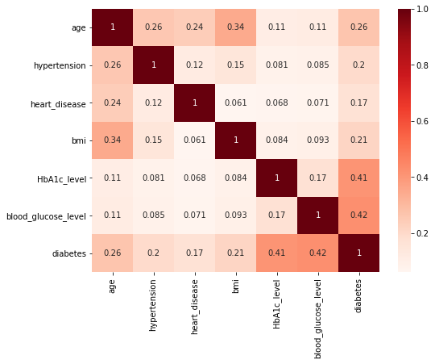

```python
warnings.filterwarnings('ignore')
fig, ax = plt.subplots(figsize=(8, 6))
sns.heatmap(df.corr(), annot = True, cmap = 'Reds')
plt.show()
```

Based on the given correlation, we see that `HbA1c_level` and `blood_glucose_level` have higher correlation with diabetes compared to others.

### Exploring Variables

#### Age distribution

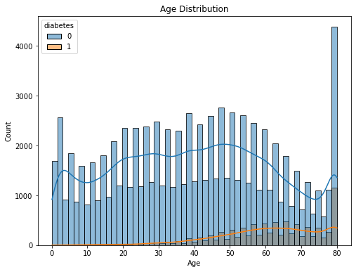

```python
fig, ax = plt.subplots(figsize=(8, 6))
sns.histplot(data=df, x="age", hue="diabetes", kde=True, ax=ax)
plt.title("Age Distribution")
plt.xlabel("Age")
```

#### BMI distribution

```
(0.0, 1500.0)
```

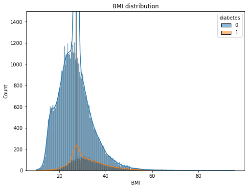

```python
fig, ax = plt.subplots(figsize=(8, 6))
sns.histplot(data=df, x="bmi", hue="diabetes", kde=True, ax=ax)
plt.title("BMI distribution")
plt.xlabel("BMI")
plt.ylim(0,1500)
```

#### Hypertension distribution

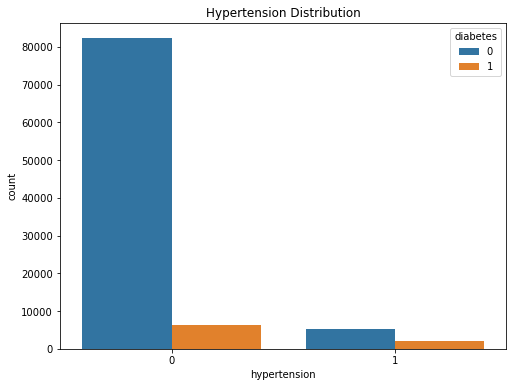

```python
fig, ax = plt.subplots(figsize=(8, 6))
sns.countplot(data=df, x='hypertension', hue="diabetes", ax=ax)
ax.set_title('Hypertension Distribution')
ax.set_xlabel("hypertension")
```

#### Heart Disease distribution

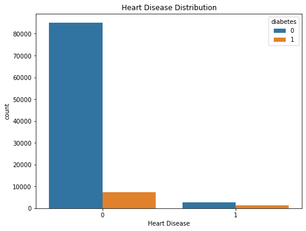

```python
fig, ax = plt.subplots(figsize=(8, 6))
sns.countplot(data=df, x='heart_disease', hue="diabetes", ax=ax)
ax.set_title('Heart Disease Distribution')
ax.set_xlabel("Heart Disease")
```

#### HbA1c Level disbribution

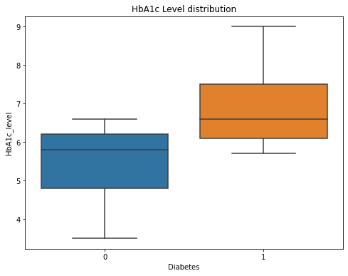

```python
fig, ax = plt.subplots(figsize=(8, 6))
sns.boxplot(data=df, x="diabetes", y='HbA1c_level')
plt.title('HbA1c Level distribution')
plt.xlabel("Diabetes")
```

#### Blood Glucose Level distribution

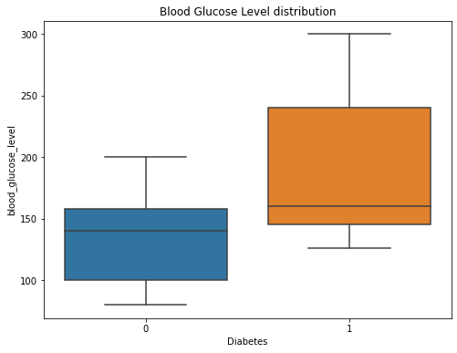

```python
fig, ax = plt.subplots(figsize=(8, 6))
sns.boxplot(data=df, x="diabetes", y='blood_glucose_level')
plt.title('Blood Glucose Level distribution')
plt.xlabel("Diabetes")
```

#### Pairplot across variables

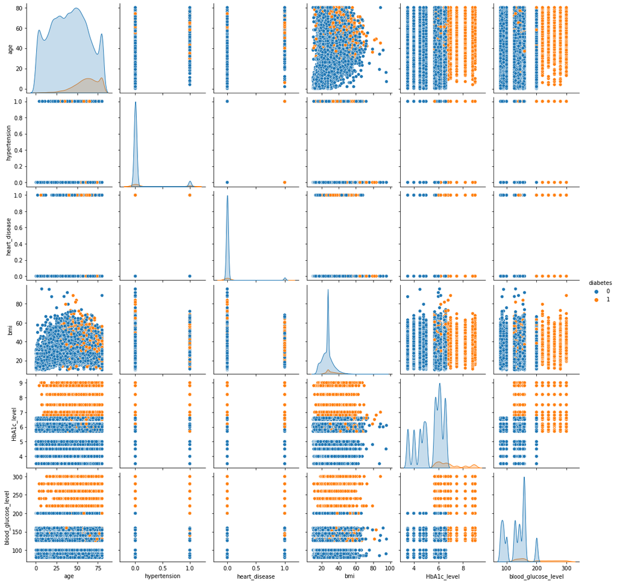

```python
sns.pairplot(df, hue='diabetes')
plt.show()
```

# Results

**OUTLINE**

- Transform our training data: Z-score or StandardScaler: age/BMI levels/HbA1c levels/blood glucose levels One hot encode categoricals: gender/smoking history
- Train each algorithm separately using the training data:
  - Logistic Regression
  - Decision Tree
  - Random Forest
  - K-Nearest Neighbor
  - Support Vector Machine
- Run Grid/Random Search as a form of cross validation on each:
  - Logistic Regression(find optimal solver, penalty term, and regularization strength)
  - Decision Tree(find optimal tree depth, etc.)
  - K-Nearest Neighbor(find optimal k)
  - Random Forest (find optima tree depth, etc.)
  - Support Vector Machine(find optimal kernel, degree, gamma, C, etc.)
- Decision
  - Recall and accuracy score
  - Parsimony principle

### Importing Packages for Machine Learning Algorithms

```python
# Scklearn packages
from sklearn.compose import ColumnTransformer
from sklearn.pipeline import Pipeline, make_pipeline
from sklearn.preprocessing import StandardScaler, OneHotEncoder
from sklearn.model_selection import train_test_split, GridSearchCV, RandomizedSearchCV
from sklearn.linear_model import LogisticRegression
from sklearn.neighbors import KNeighborsClassifier
from sklearn.svm import SVC
from sklearn.tree import DecisionTreeClassifier, plot_tree
from sklearn.ensemble import RandomForestClassifier
from scipy.stats import randint, uniform


# For error metrics
from sklearn.metrics import accuracy_score, classification_report
from sklearn.metrics import ConfusionMatrixDisplay
from sklearn.metrics import roc_auc_score, roc_curve, auc, RocCurveDisplay
from sklearn.metrics import PrecisionRecallDisplay
```

## Binary Classification

### Data Preprocessing

```python
num_variables = ['age','bmi','HbA1c_level','blood_glucose_level','hypertension','heart_disease']
cat_variables = ['gender','smoking_history']
preprocessor = ColumnTransformer(
    transformers=[
        ('num', StandardScaler(), num_variables),
        ('cat', OneHotEncoder(), cat_variables)
    ])
```

ColumnTransformer for standardizing variables and one-hot encode categorical data.

```python
X = df.drop('diabetes', axis=1)
y = df['diabetes']
```

Keeping the truth value to `y` and having our design matrix on `X`.

### Logistic Classification

```python
pipe = Pipeline(
    steps=[("preprocessor", preprocessor), ("classifier", LogisticRegression(class_weight= 'balanced', solver = 'saga', max_iter=10000))]
)
search_space = {'classifier__C': (np.logspace(-4, 1, 6)),
               'classifier__penalty': ['l2', 'l1']}
```

```python
best_model = GridSearchCV(pipe, search_space, cv=5, verbose=3)
```

```python
X_train, X_test, y_train, y_test = train_test_split(X, y, test_size=0.2, random_state=0)
```

```python
# best_model.fit(X_train, y_train)
```

```python
# joblib.dump(best_model, "LogisticClassification.joblib")
```

```python
best_model = joblib.load("LogisticClassification.joblib")
```

```python
best_model.best_params_, best_model.best_score_
```

```
({'classifier__C': 0.0001, 'classifier__penalty': 'l2'}, 0.8946773354259919)
```

```python
log_results = pd.DataFrame(best_model.cv_results_['params'])
log_results['accuracy'] = best_model.cv_results_['mean_test_score']
log_results['classifier'] = "Logistic"
log_results.rename(columns={'classifier__C': 'C','classifier__penalty':'penalty'}, inplace=True)
log_results = log_results[['classifier', 'C', 'penalty', 'accuracy']]
log_results
```

|  | classifier | C | penalty | accuracy |
| --- | --- | --- | --- | --- |
| 0 | Logistic | 0.0001 | l2 | 0.894677 |
| 1 | Logistic | 0.0001 | l1 | 0.875202 |
| 2 | Logistic | 0.0010 | l2 | 0.889334 |
| 3 | Logistic | 0.0010 | l1 | 0.886565 |
| 4 | Logistic | 0.0100 | l2 | 0.887332 |
| 5 | Logistic | 0.0100 | l1 | 0.886409 |
| 6 | Logistic | 0.1000 | l2 | 0.886994 |
| 7 | Logistic | 0.1000 | l1 | 0.886812 |
| 8 | Logistic | 1.0000 | l2 | 0.886877 |
| 9 | Logistic | 1.0000 | l1 | 0.886864 |
| 10 | Logistic | 10.0000 | l2 | 0.886890 |
| 11 | Logistic | 10.0000 | l1 | 0.886890 |

#### Error metric for Logistic Classification

```python
yhat_train = best_model.predict(X_train)
yhat_test = best_model.predict(X_test)
```

```python
acc_train = accuracy_score(y_train, yhat_train)
acc_test = accuracy_score(y_test, yhat_test)

print(f'training set accuracy (n={y_train.shape[0]}): {acc_train:4.3f}')
print(f'test set accuracy (n={y_test.shape[0]}): {acc_test:4.3f}')
print()
print('classificiation report on test set performance')
print(classification_report(y_test, yhat_test))
print()
```

```
training set accuracy (n=76916): 0.895
test set accuracy (n=19230): 0.892

classificiation report on test set performance
              precision    recall  f1-score   support

           0       0.99      0.89      0.94     17562
           1       0.44      0.87      0.58      1668

    accuracy                           0.89     19230
   macro avg       0.71      0.88      0.76     19230
weighted avg       0.94      0.89      0.91     19230
```

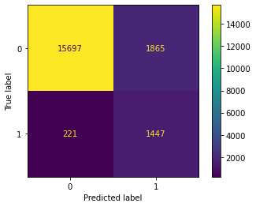

```python
ConfusionMatrixDisplay.from_predictions(y_test, yhat_test)
plt.show()
```

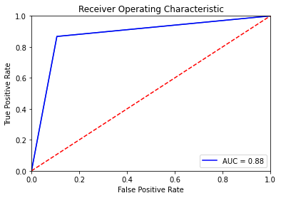

```python
fpr, tpr, thresholds = roc_curve(y_test, yhat_test)
roc_auc = auc(fpr, tpr)
roc_display=RocCurveDisplay(fpr=fpr, tpr=tpr)

roc_display.plot()
plt.title('Receiver Operating Characteristic')
plt.plot(fpr, tpr, 'b', label = 'AUC = %0.2f' % roc_auc)
plt.legend(loc = 'lower right')
plt.plot([0, 1], [0, 1],'r--')
plt.xlim([0, 1])
plt.ylim([0, 1])
plt.ylabel('True Positive Rate')
plt.xlabel('False Positive Rate')
```

```python
# Saving the result to combine later
report = classification_report(y_test, yhat_test, output_dict=True)
weighted_recall = report['weighted avg']['recall']
weighted_prec = report['weighted avg']['precision']
log_results = log_results[['classifier', 'accuracy']]
log_results = log_results.iloc[[0]]
log_results['weighted recall'] = weighted_recall
log_results['weighted precision'] = weighted_prec
log_results
```

|  | classifier | accuracy | weighted recall | weighted precision |
| --- | --- | --- | --- | --- |
| 0 | Logistic | 0.894677 | 0.891524 | 0.938477 |

#### Logistic Classifier Logistics and Results

Using this result of optimal hyperparamter it has shown the accuracy for training data to be 89.5% and test data to be 89.2%. we have created the error metrics and the ROC-AUC. Since the unseen data (test data) performs similar to the trained data suggests that there was no overfit. Also we are mostly concerned with the recall due to the nature of medical data (we want low false negatives meaning we do not want to miss people with diabetes), we do have good weighted average of recall (takes account for imbalanced data) at 89%. This is also visuallized in the error metrics that our false negative is relatively lower than the false positive indicating a high recall $\frac{TP}{TP+FN}$. Lastly, our ROC-AUC curve also lies well above the chance level indicating the model is good.

### Decision Tree

```python
pipe = Pipeline(
    steps=[("preprocessor", preprocessor), ("classifier", DecisionTreeClassifier(class_weight = 'balanced'))]
)
search_space = {'classifier__max_depth': np.arange(5,15),
               'classifier__min_samples_split': np.arange(3,8),
               'classifier__criterion': ['gini','entropy']}
```

```python
best_model = GridSearchCV(pipe, search_space, cv=5, verbose=3)
```

```python
X_train, X_test, y_train, y_test = train_test_split(X, y, test_size=0.2, random_state=0)
```

```python
# best_model.fit(X_train, y_train)
```

```python
# joblib.dump(best_model, "DecisionTree.joblib")
```

```python
best_model = joblib.load("DecisionTree.joblib")
```

```python
best_model.best_params_, best_model.best_score_
```

```
({'classifier__criterion': 'gini',
  'classifier__max_depth': 13,
  'classifier__min_samples_split': 7},
 0.9004499356337773)
```

```python
dt_results = pd.DataFrame(best_model.cv_results_['params'])
dt_results['accuracy'] = best_model.cv_results_['mean_test_score']
dt_results['classifier'] = "Decision Tree"
dt_results.rename(columns={'classifier__criterion': 'criterion', 'classifier__max_depth': 'max depth', 'classifier__min_samples_split': 'min samples split'}, inplace=True)
dt_results = dt_results[['classifier', 'criterion', 'max depth', 'min samples split', 'accuracy']]
dt_results = dt_results.sort_values('accuracy', ascending=False)
dt_results
```

|  | classifier | criterion | max depth | min samples split | accuracy |
| --- | --- | --- | --- | --- | --- |
| 44 | Decision Tree | gini | 13 | 7 | 0.900450 |
| 40 | Decision Tree | gini | 13 | 3 | 0.900450 |
| 41 | Decision Tree | gini | 13 | 4 | 0.900437 |
| 43 | Decision Tree | gini | 13 | 6 | 0.900294 |
| 42 | Decision Tree | gini | 13 | 5 | 0.900268 |
| ... | ... | ... | ... | ... | ... |
| 54 | Decision Tree | entropy | 5 | 7 | 0.803084 |
| 53 | Decision Tree | entropy | 5 | 6 | 0.803084 |
| 52 | Decision Tree | entropy | 5 | 5 | 0.803084 |
| 51 | Decision Tree | entropy | 5 | 4 | 0.803084 |
| 50 | Decision Tree | entropy | 5 | 3 | 0.803084 |

100 rows × 5 columns

#### Error Metrics for Decision Tree

```python
yhat_train = best_model.predict(X_train)
yhat_test = best_model.predict(X_test)
```

```python
acc_train = accuracy_score(y_train, yhat_train)
acc_test = accuracy_score(y_test, yhat_test)

print(f'training set accuracy (n={y_train.shape[0]}): {acc_train:4.3f}')
print(f'test set accuracy (n={y_test.shape[0]}): {acc_test:4.3f}')
print()
print('classificiation report on test set performance')
print(classification_report(y_test, yhat_test))
print()
```

```
training set accuracy (n=76916): 0.909
test set accuracy (n=19230): 0.900

classificiation report on test set performance
              precision    recall  f1-score   support

           0       0.99      0.90      0.94     17562
           1       0.46      0.90      0.61      1668

    accuracy                           0.90     19230
   macro avg       0.73      0.90      0.78     19230
weighted avg       0.94      0.90      0.91     19230
```

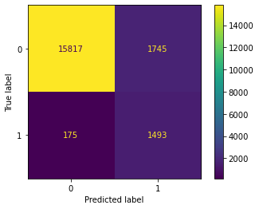

```python
ConfusionMatrixDisplay.from_predictions(y_test, yhat_test)
plt.show()
```

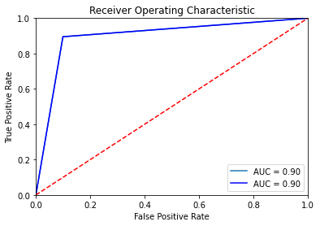

```python
fpr, tpr, thresholds = roc_curve(y_test, yhat_test)
roc_auc = auc(fpr, tpr)
roc_display=RocCurveDisplay(fpr=fpr, tpr=tpr, roc_auc=roc_auc)

roc_display.plot()
plt.title('Receiver Operating Characteristic')
plt.plot(fpr, tpr, 'b', label = 'AUC = %0.2f' % roc_auc)
plt.legend(loc = 'lower right')
plt.plot([0, 1], [0, 1],'r--')
plt.xlim([0, 1])
plt.ylim([0, 1])
plt.ylabel('True Positive Rate')
plt.xlabel('False Positive Rate')
plt.show();
```

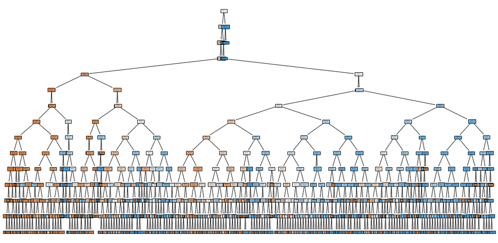

```python
# plot the decision tree
num_variables = ['age', 'bmi', 'HbA1c_level', 'blood_glucose_level','hypertension','heart_disease']
cat_variables = ['gender','smoking_history']

preprocessor = ColumnTransformer(
    transformers=[
        ('num', StandardScaler(), num_variables),
        ('cat', OneHotEncoder(), cat_variables)
    ])

pipe = make_pipeline(preprocessor, DecisionTreeClassifier(class_weight='balanced', criterion='gini', max_depth=14, min_samples_split=3))

pipe.fit(X, y)

decision_tree = pipe.named_steps['decisiontreeclassifier']

transformer_names = preprocessor.transformers_
feature_names = []

for transformer_name in transformer_names:
    if isinstance(transformer_name[1], OneHotEncoder):
        feature_names.extend(transformer_name[1].get_feature_names_out())
    else:
        feature_names.extend(transformer_name[2])

class_names = [str(class_label) for class_label in decision_tree.classes_]


plt.figure(figsize=(20, 10))
plot_tree(decision_tree, feature_names=feature_names, class_names=class_names, filled=True)
plt.show()
```

```python
report = classification_report(y_test, yhat_test, output_dict=True)
weighted_recall = report['weighted avg']['recall']
dt_results = dt_results[['classifier', 'accuracy']]
dt_results = dt_results.iloc[[0]]
dt_results['weighted recall'] = weighted_recall
weighted_prec = report['weighted avg']['precision']
dt_results['weighted precision'] = weighted_prec
dt_results
```

|  | classifier | accuracy | weighted recall | weighted precision |
| --- | --- | --- | --- | --- |
| 44 | Decision Tree | 0.90045 | 0.900156 | 0.943261 |

#### Decision Tree Logistics and Results

In the above, we used a decision tree classifier to perform binary classification on our patient observations. First, we started by creating a pipeline in which we fed in the preprocessed training data and our decision tree classifier. Within the classifier, we set the class weight to "balanced" because this allowed our model to effectively deal with unbalanced data. Our data can be considered "unbalanced" because a large majority of our patients' do not have diabetes, and interestingly, roughly one in eleven possessed diabetes. Next, we set up a search space to be used in our Grid Search, and we decided to exhaustively search through the classifier's decision criteria, its max depth, and minimum sample splits. Within our search space, we used gini impurity and entropy for decision criteria. In respect to max depth and minimum sample splits, we chose appropriate ranges of integers to be exhaustively searched through. We then set up our Grid Search with 5 folds in an effort to find the best hyperparameters. Next, we split our training and testing data and used 80% of our data for training and set 20% aside for testing. We then ran our Grid Search with a total of 500 fits and created a data frame showing the different combinations of possible hyperparameters. We checked our optimal hyperparameters and then reviewed our resulting model's accuracy, confusion matrix, and ROC-AUC curve. Due to the decision tree's interpretable nature, we visualized the tree and its many nodes. The large number of decision stumps made this plot hard to understand, however, it should be noted that the plot is relatively balanced.

Within our error metrics we observed 90.9% accuracy on our training data and 90% accuracy on our testing data. Since the training and testing percentages are close, this suggests that the model performed well on unseen data and indicates that the algorithm was not overfit on the training data. Due to the fact that we are mostly concerned with recall over other metrics, a weighted average (takes account for imbalanced data) recall of 90% is good. This model's biggest downside is the low precision on the true class, which results from a large number of false positives(~10%). Our confusion matrix further highlights this and also shows the small number of false negatives! Our ROC-AUC looks great, as it lies far above the chance performance level and has 0.90 area under the curve. This suggests that this decision tree classifier has good overall performance in distinguishing between the positive and negative class.

### Random Forest

```python
pipe = Pipeline(
    steps=[("preprocessor", preprocessor), ("classifier", RandomForestClassifier(class_weight = 'balanced'))]
)
search_space = {'classifier__n_estimators': randint(100,500),
                'classifier__max_depth': randint(5,20),
               'classifier__min_samples_split': randint(2,20),
               'classifier__criterion': ['gini','entropy']}
```

```python
best_model = RandomizedSearchCV(pipe, search_space, n_iter = 25, cv=5, verbose=3)
```

```python
X_train, X_test, y_train, y_test = train_test_split(X, y, test_size=0.2, random_state=0)
```

```python
# best_model.fit(X_train, y_train)
```

```python
# joblib.dump(best_model, "RandomForest.joblib")
```

```python
best_model = joblib.load("RandomForest.joblib")
```

```python
best_model.best_params_, best_model.best_score_
```

```
({'classifier__criterion': 'entropy',
  'classifier__max_depth': 19,
  'classifier__min_samples_split': 8,
  'classifier__n_estimators': 228},
 0.955665971097012)
```

```python
rf_results = pd.DataFrame(best_model.cv_results_['params'])
rf_results['accuracy'] = best_model.cv_results_['mean_test_score']
rf_results['classifier'] = "Random Forest"
rf_results.rename(columns={'classifier__criterion': 'criterion', 'classifier__max_depth': 'max depth', 'classifier__min_samples_split': 'min samples split', 'classifier__n_estimators': 'num estimators'}, inplace=True)
rf_results = rf_results[['classifier', 'criterion', 'max depth', 'min samples split', 'num estimators', 'accuracy']]
rf_results = rf_results.sort_values('accuracy', ascending=False)
rf_results
```

|  | classifier | criterion | max depth | min samples split | num estimators | accuracy |
| --- | --- | --- | --- | --- | --- | --- |
| 22 | Random Forest | entropy | 19 | 8 | 228 | 0.955666 |
| 5 | Random Forest | gini | 18 | 7 | 268 | 0.952949 |
| 1 | Random Forest | gini | 19 | 15 | 307 | 0.946851 |
| 0 | Random Forest | gini | 18 | 14 | 128 | 0.945590 |
| 12 | Random Forest | entropy | 17 | 14 | 185 | 0.941963 |
| 3 | Random Forest | entropy | 16 | 18 | 339 | 0.935371 |
| 4 | Random Forest | gini | 15 | 7 | 166 | 0.934435 |
| 6 | Random Forest | gini | 15 | 18 | 236 | 0.928311 |
| 10 | Random Forest | entropy | 14 | 15 | 358 | 0.926582 |
| 15 | Random Forest | gini | 13 | 9 | 252 | 0.920186 |
| 2 | Random Forest | entropy | 12 | 11 | 358 | 0.918665 |
| 8 | Random Forest | entropy | 11 | 15 | 223 | 0.916181 |
| 20 | Random Forest | entropy | 11 | 8 | 127 | 0.915154 |
| 16 | Random Forest | entropy | 7 | 11 | 155 | 0.914738 |
| 7 | Random Forest | gini | 5 | 2 | 119 | 0.914062 |
| 11 | Random Forest | entropy | 8 | 13 | 177 | 0.913789 |
| 17 | Random Forest | entropy | 8 | 6 | 353 | 0.913685 |
| 18 | Random Forest | entropy | 9 | 12 | 235 | 0.913035 |
| 24 | Random Forest | gini | 5 | 9 | 357 | 0.912047 |
| 23 | Random Forest | gini | 10 | 11 | 317 | 0.907757 |
| 9 | Random Forest | gini | 10 | 12 | 104 | 0.907653 |
| 13 | Random Forest | gini | 9 | 19 | 440 | 0.906456 |
| 19 | Random Forest | gini | 9 | 6 | 489 | 0.906131 |
| 21 | Random Forest | gini | 9 | 14 | 172 | 0.905767 |
| 14 | Random Forest | gini | 9 | 13 | 106 | 0.904233 |

#### Error Metrics for Random Forest

```python
yhat_train = best_model.predict(X_train)
yhat_test = best_model.predict(X_test)
```

```python
acc_train = accuracy_score(y_train, yhat_train)
acc_test = accuracy_score(y_test, yhat_test)

print(f'training set accuracy (n={y_train.shape[0]}): {acc_train:4.3f}')
print(f'test set accuracy (n={y_test.shape[0]}): {acc_test:4.3f}')
print()
print('classificiation report on test set performance')
print(classification_report(y_test, yhat_test))
print()
```

```
training set accuracy (n=76916): 0.978
test set accuracy (n=19230): 0.953

classificiation report on test set performance
              precision    recall  f1-score   support

           0       0.98      0.97      0.97     17562
           1       0.70      0.80      0.75      1668

    accuracy                           0.95     19230
   macro avg       0.84      0.89      0.86     19230
weighted avg       0.96      0.95      0.95     19230
```

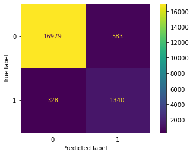

```python
ConfusionMatrixDisplay.from_predictions(y_test, yhat_test)
plt.show()
```

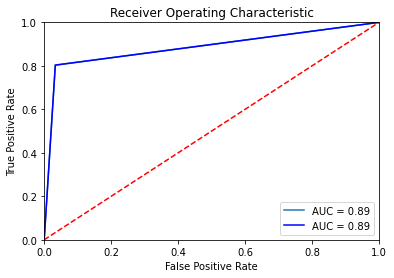

```python
fpr, tpr, thresholds = roc_curve(y_test, yhat_test)
roc_auc = auc(fpr, tpr)
roc_display=RocCurveDisplay(fpr=fpr, tpr=tpr, roc_auc=roc_auc)

roc_display.plot()
plt.title('Receiver Operating Characteristic')
plt.plot(fpr, tpr, 'b', label = 'AUC = %0.2f' % roc_auc)
plt.legend(loc = 'lower right')
plt.plot([0, 1], [0, 1],'r--')
plt.xlim([0, 1])
plt.ylim([0, 1])
plt.ylabel('True Positive Rate')
plt.xlabel('False Positive Rate')
plt.show();
```

```python
report = classification_report(y_test, yhat_test, output_dict=True)
weighted_recall = report['weighted avg']['recall']
rf_results = rf_results[['classifier', 'accuracy']]
rf_results = rf_results.iloc[[0]]
rf_results['weighted recall'] = weighted_recall
weighted_prec = report['weighted avg']['precision']
rf_results['weighted precision'] = weighted_prec
rf_results
```

|  | classifier | accuracy | weighted recall | weighted precision |
| --- | --- | --- | --- | --- |
| 22 | Random Forest | 0.955666 | 0.952626 | 0.956395 |

#### Random Forest Logistics and Results

In the above code, we created a random forest classifier to perform binary classification on our patient observations. We started by creating a pipeline that took in our preprocessed data as well as a random forest classifier. Similar to our other algorithms, we set the class weight to "balanced" within the pipeline to allow our model to adequately deal with the unbalanced data. Next, we initialized our search space and decided to use a Random Search to find the classifier's optimal decision criteria, max depth, minimum sample splits, and number of estimators. Given the large number of hyperparameter combinations, we felt that a Random Search would be best for finding the optimal parameters. Within our search space, we used gini impurity and entropy for decision criteria. In respect to max depth, minimum sample splits, and number of estimators, we set up ranges of integers that we felt were appropriate. We used Scipy 'randint' to randomly select integers from a given range with replacement for each of these values. Next, we set up our Random Search with 5 folds and 25 iterations(number of parameter settings sampled). We split our training and testing data in a similar fashion to our previous algorithms, and then fit the model. Our Random Search consisted of 5 folds of 25 candidates, totalling 125 fits. Following our Random Search, we created a dataframe that illustrated the performance of each of our hyperparameter combinations. Then we checked the best parameters and the associated model's accuracy score. In addition, we reviewed the model's accuracy report, confusion matrix, and ROC-AUC curve.

Our error metrics revealed 97.8% accuracy during training and 95.3% accuracy during testing. This indicates that the model performed well on new and unseen data, but there is a slight drop in performance when testing compared to training. However, the test set accuracy is still relatively high and this can suggest that the model generalized well to unseen data. Our classifier received high recall for the negative class, but lower recall for the positive class. The recall for the negative class is 97% and recall for the positive class is 80%, which suggests that the model performed better on the non-diabetic class than the diabetic class. The weighted average recall (takes account for imblalanced data) is 95%, which is pretty good. In addition, after viewing our confusion matrix, we somewhat observed a balance between false negatives and false positives, compared to some of our other algorithms. Our ROC-AUC curve provided an area under the curve of 0.89, which suggests that the model has a solid balance between the true positive rate and the false positive rate. All together, this random forest classifier is highly accurate and possesses a sufficiently high recall.

### K-Nearest Neighbor Classification

```python
pipe = Pipeline(
    steps=[("preprocessor", preprocessor), ("classifier", KNeighborsClassifier())]
)
search_space = {'classifier__n_neighbors' : np.arange(1,21,1)}
```

```python
best_model = GridSearchCV(pipe, search_space, cv=5, verbose=3)
```

```python
X_train, X_test, y_train, y_test = train_test_split(X, y, test_size=0.2, random_state=0)
```

```python
# best_model.fit(X_train, y_train)
```

```python
# joblib.dump(best_model, "KNN.joblib")
```

```python
best_model = joblib.load("KNN.joblib")
```

```python
best_model.best_params_, best_model.best_score_
```

```
({'classifier__n_neighbors': 13}, 0.9594362723348562)
```

```python
knn_results = pd.DataFrame(best_model.cv_results_['params'])
knn_results['accuracy'] = best_model.cv_results_['mean_test_score']
knn_results['classifier'] = "K-NN"
knn_results.rename(columns={'classifier__n_neighbors': 'K'}, inplace=True)
knn_results = knn_results[['classifier', 'K', 'accuracy']]
knn_results = knn_results.sort_values('accuracy', ascending=False)
knn_results
```

|  | classifier | K | accuracy |
| --- | --- | --- | --- |
| 12 | K-NN | 13 | 0.959436 |
| 16 | K-NN | 17 | 0.959254 |
| 10 | K-NN | 11 | 0.959254 |
| 14 | K-NN | 15 | 0.959202 |
| 18 | K-NN | 19 | 0.959150 |
| 8 | K-NN | 9 | 0.958994 |
| 13 | K-NN | 14 | 0.958968 |
| 9 | K-NN | 10 | 0.958916 |
| 11 | K-NN | 12 | 0.958890 |
| 17 | K-NN | 18 | 0.958864 |
| 19 | K-NN | 20 | 0.958864 |
| 15 | K-NN | 16 | 0.958851 |
| 5 | K-NN | 6 | 0.958669 |
| 7 | K-NN | 8 | 0.958630 |
| 6 | K-NN | 7 | 0.958604 |
| 3 | K-NN | 4 | 0.958435 |
| 1 | K-NN | 2 | 0.958201 |
| 4 | K-NN | 5 | 0.957824 |
| 2 | K-NN | 3 | 0.955965 |
| 0 | K-NN | 1 | 0.945954 |

#### Error metric for K-Nearest Neighbors

```python
yhat_train = best_model.predict(X_train)
yhat_test = best_model.predict(X_test)
```

```python
acc_train = accuracy_score(y_train, yhat_train)
acc_test = accuracy_score(y_test, yhat_test)

print(f'training set accuracy (n={y_train.shape[0]}): {acc_train:4.3f}')
print(f'test set accuracy (n={y_test.shape[0]}): {acc_test:4.3f}')
print()
print('classificiation report on test set performance')
print(classification_report(y_test, yhat_test))
print()
```

```
training set accuracy (n=76916): 0.963
test set accuracy (n=19230): 0.961

classificiation report on test set performance
              precision    recall  f1-score   support

           0       0.96      1.00      0.98     17562
           1       0.94      0.59      0.73      1668

    accuracy                           0.96     19230
   macro avg       0.95      0.79      0.85     19230
weighted avg       0.96      0.96      0.96     19230
```

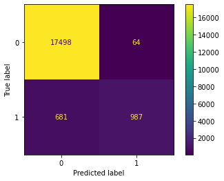

```python
ConfusionMatrixDisplay.from_predictions(y_test, yhat_test)
plt.show()
```

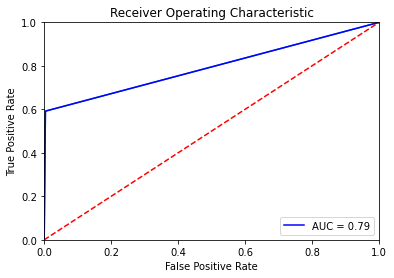

```python
fpr, tpr, thresholds = roc_curve(y_test, yhat_test)
roc_auc = auc(fpr, tpr)
roc_display=RocCurveDisplay(fpr=fpr, tpr=tpr)

roc_display.plot()
plt.title('Receiver Operating Characteristic')
plt.plot(fpr, tpr, 'b', label = 'AUC = %0.2f' % roc_auc)
plt.legend(loc = 'lower right')
plt.plot([0, 1], [0, 1],'r--')
plt.xlim([0, 1])
plt.ylim([0, 1])
plt.ylabel('True Positive Rate')
plt.xlabel('False Positive Rate')
```

```python
report = classification_report(y_test, yhat_test, output_dict=True)
weighted_recall = report['weighted avg']['recall']
knn_results = knn_results[['classifier', 'accuracy']]
knn_results = knn_results.iloc[[0]]
knn_results['weighted recall'] = weighted_recall
weighted_prec = report['weighted avg']['precision']
knn_results['weighted precision'] = weighted_prec
knn_results
```

|  | classifier | accuracy | weighted recall | weighted precision |
| --- | --- | --- | --- | --- |
| 12 | K-NN | 0.959436 | 0.961258 | 0.960507 |

#### K-Nearest Neighbors Logistics and Results

In the above code, we created a K-Nearest Neighbors classifier to perform binary classification on our patient observations. Just like other algorithms, we started by creating a pipeline that took in our preprocessed data as well as a K-Nearest Neighbors classifier. Since the KNN is not influenced by the imbalanced class we did not take account for class weights. We then initialized the search space for KNN classifier setting `K` (number of neighbors) from 1~21. We splitted our `X` and `y` in train and test set having 0.2 to be test set. Then we utilized the pipeline and search space to run grid search (exhaustive search) with $C=5$ which allowed us to have 100 fits in total. The result of grid search showed that the best hyperparameter within the range we chose was $K=13$ (13 nearest neighbors).

Using this result of optimal hyperparamter it has shown the accuracy for training data to be 96.3% and test data to be 96.1%. we have created the error metrics and the ROC-AUC to further analyze the result. Since the unseen data (test data) performs similar to the trained data suggests that there was no overfit. Also, we are mostly concerned with the recall $\frac{TP}{TP+FN}$ due to the nature of medical data (we want low false negatives meaning we do not want to miss patients with diabetes), seems like we have better precision $\frac{TP}{TP+FP}$ than recall meaning it does have more false negatives relatively compared with false positive suggesting it might not be a great model compared to other algorithms. This is also visuallized in the error metrics that our false positive is relatively lowe than the false negative indicating a high precision, but we want high recall not precision. The ROC-AUC curve lies well above the chance level indicating the model is good but we want high recall instead of high precision.

## Support Vector Machine

```python
# Create a pipeline with small C
pipe = Pipeline(steps=[("preprocessor", preprocessor),
                 ("classifier", SVC(class_weight = 'balanced', max_iter=1000))]
)

search_space = [{'classifier__kernel': ['linear'],
                'classifier__C': np.logspace(-4, 1, 6)},
                {'classifier__kernel':['rbf'],
                'classifier__C': np.logspace(-4,1,6),
                'classifier__gamma': np.logspace(-4, 1, 6)},
                {'classifier__kernel': ['poly'],
                 'classifier__gamma': np.logspace(-4, 1, 6),
                 'classifier__degree': range(2,4),
                 'classifier__C': np.logspace(-4, 1, 6)}]
```

```python
best_model = GridSearchCV(pipe, search_space, cv=4, verbose=3)
```

```python
X_train, X_test, y_train, y_test = train_test_split(X, y, test_size=0.2, random_state=0)
```

```python
# best_model.fit(X_train, y_train)
```

```python
# joblib.dump(best_model, "SVC_with_smallC.joblib")
```

```python
best_model = joblib.load("SVC_with_smallC.joblib")
```

```python
best_model.best_params_, best_model.best_score_
```

```
({'classifier__C': 10.0,
  'classifier__gamma': 10.0,
  'classifier__kernel': 'rbf'},
 0.9011649071714597)
```

```python
svc_results = pd.DataFrame(best_model.cv_results_['params'])
svc_results['accuracy'] = best_model.cv_results_['mean_test_score']
svc_results['classifier'] = "SVC"
svc_results.rename(columns={'classifier__C': 'C','classifier__gamma':'gamma','classifier__degree':'degree','classifier__kernel':'kernel'}, inplace=True)
svc_results = svc_results[['classifier','kernel','C', 'gamma', 'degree','accuracy']]
svc_results = svc_results.sort_values('accuracy', ascending=False)
svc_results
```

|  | classifier | kernel | C | gamma | degree | accuracy |
| --- | --- | --- | --- | --- | --- | --- |
| 41 | SVC | rbf | 10.0000 | 10.0000 | NaN | 0.901165 |
| 40 | SVC | rbf | 10.0000 | 1.0000 | NaN | 0.888944 |
| 39 | SVC | rbf | 10.0000 | 0.1000 | NaN | 0.584560 |
| 5 | SVC | linear | 10.0000 | NaN | NaN | 0.579749 |
| 4 | SVC | linear | 1.0000 | NaN | NaN | 0.541370 |
| ... | ... | ... | ... | ... | ... | ... |
| 42 | SVC | poly | 0.0001 | 0.0001 | 2.0 | 0.088590 |
| 36 | SVC | rbf | 10.0000 | 0.0001 | NaN | 0.088590 |
| 31 | SVC | rbf | 1.0000 | 0.0010 | NaN | 0.088590 |
| 30 | SVC | rbf | 1.0000 | 0.0001 | NaN | 0.088590 |
| 57 | SVC | poly | 0.0010 | 0.1000 | 2.0 | 0.088590 |

114 rows × 6 columns

#### Error Metrics for Support Vector Machine - Small C

```python
yhat_train = best_model.predict(X_train)
yhat_test = best_model.predict(X_test)
```

```python
acc_train = accuracy_score(y_train, yhat_train)
acc_test = accuracy_score(y_test, yhat_test)

print(f'training set accuracy (n={y_train.shape[0]}): {acc_train:4.3f}')
print(f'test set accuracy (n={y_test.shape[0]}): {acc_test:4.3f}')
print()
print('classificiation report on test set performance')
print(classification_report(y_test, yhat_test))
print()
```

[output not shown]

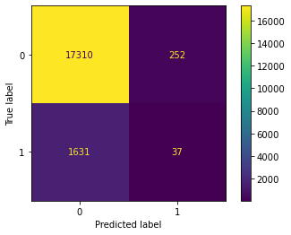

```python
ConfusionMatrixDisplay.from_predictions(y_test, yhat_test)
plt.show()
```

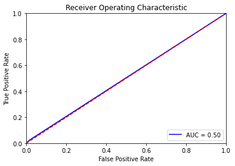

```python
fpr, tpr, thresholds = roc_curve(y_test, yhat_test)
roc_auc = auc(fpr, tpr)
roc_display=RocCurveDisplay(fpr=fpr, tpr=tpr)

roc_display.plot()
plt.title('Receiver Operating Characteristic')
plt.plot(fpr, tpr, 'b', label = 'AUC = %0.2f' % roc_auc)
plt.legend(loc = 'lower right')
plt.plot([0, 1], [0, 1],'r--')
plt.xlim([0, 1])
plt.ylim([0, 1])
plt.ylabel('True Positive Rate')
plt.xlabel('False Positive Rate')
```

```python
# Saving the result to combine later
report = classification_report(y_test, yhat_test, output_dict=True)
weighted_recall = report['weighted avg']['recall']
weighted_prec = report['weighted avg']['precision']
svc_results = svc_results[['classifier', 'accuracy']]
svc_results = svc_results.iloc[[0]]
svc_results['weighted recall'] = weighted_recall
svc_results['weighted precision'] = weighted_prec
svc_results
```

|  | classifier | accuracy | weighted recall | weighted precision |
| --- | --- | --- | --- | --- |
| 41 | SVC | 0.901165 | 0.90208 | 0.845725 |

```python
# Create a new pipeline with Big C based on previous result
pipe = Pipeline([('make_features', preprocessor),
                 ('classifier', SVC(class_weight = 'balanced', max_iter=1000))]
)

search_space = [{'classifier__kernel': ['linear'],
                'classifier__C': np.logspace(1, 4, 4)},
                {'classifier__kernel':['rbf'],
                'classifier__C': np.logspace(1,4,4),
                'classifier__gamma': np.logspace(-1, 2, 4)}, #Made gamma higher
                {'classifier__kernel': ['poly'],
                 'classifier__gamma': np.logspace(-1, 2, 4),#Made gamma higher
                 'classifier__degree': range(2,4),
                 'classifier__C': np.logspace(1, 4, 4)}]
```

```python
best_model = GridSearchCV(pipe, search_space, cv=4, verbose=3)
```

```python
X_train, X_test, y_train, y_test = train_test_split(X, y, test_size=0.2, random_state=0)
```

```python
# best_model.fit(X_train, y_train)
```

```python
# joblib.dump(best_model, "SVC_with_BigC.joblib")
```

```python
best_model = joblib.load("SVC_with_BigC.joblib")
```

```python
best_model.best_params_, best_model.best_score_
```

```
({'classifier__C': 1000.0,
  'classifier__gamma': 100.0,
  'classifier__kernel': 'rbf'},
 0.905559311456654)
```

```python
svc_results = pd.DataFrame(best_model.cv_results_['params'])
svc_results['accuracy'] = best_model.cv_results_['mean_test_score']
svc_results['classifier'] = "SVC"
svc_results.rename(columns={'classifier__C': 'C','classifier__gamma':'gamma','classifier__degree':'degree','classifier__kernel':'kernel'}, inplace=True)
svc_results = svc_results[['classifier','kernel','C', 'gamma', 'degree','accuracy']]
svc_results = svc_results.sort_values('accuracy', ascending=False)
svc_results
```

|  | classifier | kernel | C | gamma | degree | accuracy |
| --- | --- | --- | --- | --- | --- | --- |
| 15 | SVC | rbf | 1000.0 | 100.0 | NaN | 0.905559 |
| 19 | SVC | rbf | 10000.0 | 100.0 | NaN | 0.905559 |
| 11 | SVC | rbf | 100.0 | 100.0 | NaN | 0.905533 |
| 7 | SVC | rbf | 10.0 | 100.0 | NaN | 0.905156 |
| 14 | SVC | rbf | 1000.0 | 10.0 | NaN | 0.904909 |
| 10 | SVC | rbf | 100.0 | 10.0 | NaN | 0.904233 |
| 18 | SVC | rbf | 10000.0 | 10.0 | NaN | 0.904142 |
| 17 | SVC | rbf | 10000.0 | 1.0 | NaN | 0.903674 |
| 6 | SVC | rbf | 10.0 | 10.0 | NaN | 0.901165 |
| 9 | SVC | rbf | 100.0 | 1.0 | NaN | 0.898149 |
| 13 | SVC | rbf | 1000.0 | 1.0 | NaN | 0.895028 |
| 5 | SVC | rbf | 10.0 | 1.0 | NaN | 0.888944 |
| 12 | SVC | rbf | 1000.0 | 0.1 | NaN | 0.836796 |
| 16 | SVC | rbf | 10000.0 | 0.1 | NaN | 0.779097 |
| 8 | SVC | rbf | 100.0 | 0.1 | NaN | 0.770139 |
| 3 | SVC | linear | 10000.0 | NaN | NaN | 0.684084 |
| 2 | SVC | linear | 1000.0 | NaN | NaN | 0.684084 |
| 4 | SVC | rbf | 10.0 | 0.1 | NaN | 0.584560 |
| 0 | SVC | linear | 10.0 | NaN | NaN | 0.579749 |
| 1 | SVC | linear | 100.0 | NaN | NaN | 0.562705 |
| 37 | SVC | poly | 1000.0 | 1.0 | 2.0 | 0.542735 |
| 22 | SVC | poly | 10.0 | 10.0 | 2.0 | 0.493369 |
| 30 | SVC | poly | 100.0 | 10.0 | 2.0 | 0.449217 |
| 46 | SVC | poly | 10000.0 | 10.0 | 2.0 | 0.449217 |
| 38 | SVC | poly | 1000.0 | 10.0 | 2.0 | 0.449217 |
| 45 | SVC | poly | 10000.0 | 1.0 | 2.0 | 0.436112 |
| 21 | SVC | poly | 10.0 | 1.0 | 2.0 | 0.410877 |
| 42 | SVC | poly | 1000.0 | 10.0 | 3.0 | 0.401321 |
| 34 | SVC | poly | 100.0 | 10.0 | 3.0 | 0.401321 |
| 26 | SVC | poly | 10.0 | 10.0 | 3.0 | 0.401321 |
| 50 | SVC | poly | 10000.0 | 10.0 | 3.0 | 0.395730 |
| 33 | SVC | poly | 100.0 | 1.0 | 3.0 | 0.388060 |
| 40 | SVC | poly | 1000.0 | 0.1 | 3.0 | 0.374551 |
| 41 | SVC | poly | 1000.0 | 1.0 | 3.0 | 0.345065 |
| 49 | SVC | poly | 10000.0 | 1.0 | 3.0 | 0.345065 |
| 48 | SVC | poly | 10000.0 | 0.1 | 3.0 | 0.338070 |
| 29 | SVC | poly | 100.0 | 1.0 | 2.0 | 0.331791 |
| 44 | SVC | poly | 10000.0 | 0.1 | 2.0 | 0.325992 |
| 43 | SVC | poly | 1000.0 | 100.0 | 3.0 | 0.317294 |
| 25 | SVC | poly | 10.0 | 1.0 | 3.0 | 0.316241 |
| 35 | SVC | poly | 100.0 | 100.0 | 3.0 | 0.315682 |
| 51 | SVC | poly | 10000.0 | 100.0 | 3.0 | 0.306828 |
| 39 | SVC | poly | 1000.0 | 100.0 | 2.0 | 0.301524 |
| 31 | SVC | poly | 100.0 | 100.0 | 2.0 | 0.301524 |
| 23 | SVC | poly | 10.0 | 100.0 | 2.0 | 0.301524 |
| 47 | SVC | poly | 10000.0 | 100.0 | 2.0 | 0.301524 |
| 36 | SVC | poly | 1000.0 | 0.1 | 2.0 | 0.284362 |
| 27 | SVC | poly | 10.0 | 100.0 | 3.0 | 0.283452 |
| 20 | SVC | poly | 10.0 | 0.1 | 2.0 | 0.242043 |
| 28 | SVC | poly | 100.0 | 0.1 | 2.0 | 0.240054 |
| 24 | SVC | poly | 10.0 | 0.1 | 3.0 | 0.138346 |
| 32 | SVC | poly | 100.0 | 0.1 | 3.0 | 0.126073 |

#### Error metric for Support Vector Machine - Large C

```python
yhat_train = best_model.predict(X_train)
yhat_test = best_model.predict(X_test)
```

```python
acc_train = accuracy_score(y_train, yhat_train)
acc_test = accuracy_score(y_test, yhat_test)

print(f'training set accuracy (n={y_train.shape[0]}): {acc_train:4.3f}')
print(f'test set accuracy (n={y_test.shape[0]}): {acc_test:4.3f}')
print()
print('classificiation report on test set performance')
print(classification_report(y_test, yhat_test))
print()
```

```
training set accuracy (n=76916): 0.921
test set accuracy (n=19230): 0.908

classificiation report on test set performance
              precision    recall  f1-score   support

           0       0.91      0.99      0.95     17562
           1       0.13      0.01      0.02      1668

    accuracy                           0.91     19230
   macro avg       0.52      0.50      0.49     19230
weighted avg       0.85      0.91      0.87     19230
```

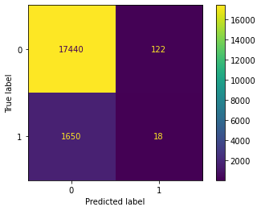

```python
ConfusionMatrixDisplay.from_predictions(y_test, yhat_test)
plt.show()
```

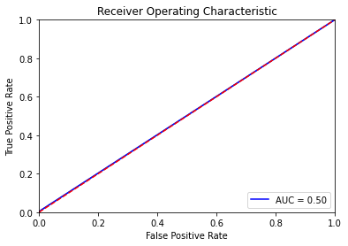

```python
fpr, tpr, thresholds = roc_curve(y_test, yhat_test)
roc_auc = auc(fpr, tpr)
roc_display=RocCurveDisplay(fpr=fpr, tpr=tpr)

roc_display.plot()
plt.title('Receiver Operating Characteristic')
plt.plot(fpr, tpr, 'b', label = 'AUC = %0.2f' % roc_auc)
plt.legend(loc = 'lower right')
plt.plot([0, 1], [0, 1],'r--')
plt.xlim([0, 1])
plt.ylim([0, 1])
plt.ylabel('True Positive Rate')
plt.xlabel('False Positive Rate')
```

```python
# Saving the result to combine later
report = classification_report(y_test, yhat_test, output_dict=True)
weighted_recall = report['weighted avg']['recall']
weighted_prec = report['weighted avg']['precision']
svc_results = svc_results[['classifier', 'accuracy']]
svc_results = svc_results.iloc[[0]]
svc_results['weighted recall'] = weighted_recall
svc_results['weighted precision'] = weighted_prec
svc_results
```

|  | classifier | accuracy | weighted recall | weighted precision |
| --- | --- | --- | --- | --- |
| 15 | SVC | 0.905559 | 0.907852 | 0.845477 |

#### Support Vector Machine Logistics and Results

However, looking at the accuracy per kernels, C, and gamma, we realized that accuracy was poor with very low C and gamma value. It cared more about maximizing margin than hinge loss. Instead of only trying soft margin, we thought it would be useful to try hard margin with big C value where we care more about hinge loss than maximizing margin as well. We repeated the pipeline process with bigger C and bigger gamma. We checked the best parameters and the associated model's accuracy score. In addition, we reviewed the model's accuracy report, confusion matrix, and ROC-AUC curve for both pipelines for soft margin and hard margin.

For small C value it had 90.2% accuracy, 90.2% weighted recall, and 84.6% weighted precision. For big C value, it had 90.6% accuracy, 90.8% weighted recall, and 84.6% weighted precision. However, according to confusion matrix, recall for the positive (1) for both C values are less than 3% which is significantly less than negative recall. Since we care about recall for detecting diabetes the most, ROC-AUC curve for both were poor which indicates that the model is not predictive and have same result as random guessing model. This is because a random guessing model will have an equal probability of guessing a correct and incorrect answer, so the true positive rate (TPR) and false positive rate (FPR) values are both very low. This results in a diagonal line when plotted on the ROC-AUC curve. We come to realize that SVC model for our data is not predictive as well as time exhaustive, and thus should not be used.

# Discussion

In order to begin our investigation, we did some exploratory data analysis including data cleaning and gathering descriptive statistics in order to get a general understanding of our dataset. More specifically, we first dropped duplicate values from our dataset, as our results would be skewed if certain patients are counted for twice in our analysis. Then we checked for missing observations to get a sense of where the data might be lacking, however, there were no missing values for any of the columns in our dataset. Next, we gathered descriptive statistics on our dataset including the count, mean, standard deviation, minimum, quartiles, and maximum of our variables. After this, we created a heatmap to see which variables are most correlated with each other and then we explored each variable individually by looking at their respective distributions. Lastly, we created a pair plot across all variables to better visually understand the distributions and their relationships with one another. Finally, we preprocessed our numerical and categorical variables using a column transformer to standardize our data.

After completing our exploratory data analysis, we chose which algorithms we would use to analyze our data. We decided that logistic classification, decision trees, random forest, k-nearest neighbor, and support vector machine would be the best algorithms to analyze our data. Each of these algorithms are equipped for binary classification tasks and we believed that each one would give us different insights, thus allowing us to compare and contrast their strengths and weaknesses. For each algorithm, we tested different combinations of hyperparameters through one of two types of cross-validation; Grid Search or Random Search. On algorithms that we felt had too large a number of hyperparameter combinations, we used RandomizedSearchCV since Grid Search or an exhaustive search would be too computationally expensive. Otherwise, with a smaller number of hyperparameters, we used GridSearchCV because it exhaustively searches through the provided hyperparameter search space. Lastly, for each algorithm, we selected the combination of hyperparameters that provided the best accuracy score.

After training each algorithm with the optimal hyperparameters, we proposed multiple error metrics to evaluate the strengths and weaknesses of our algorithm. The five main error metrics we considered were confusion matrices, ROC-AUCs, accuracy, weighted recall, and weighted precision values. It is important to note that while all these metrics provide us with nuanced differences for evaluating the performance of a model, we will be considering all of these error metrics, in addition to the parsimony principle, when choosing our final algorithm

### Combined Results

```python
merged_df = pd.concat([log_results, dt_results, rf_results, knn_results], ignore_index=True)
merged_df
```

|  | classifier | accuracy | weighted recall | weighted precision |
| --- | --- | --- | --- | --- |
| 0 | Logistic | 0.894677 | 0.891524 | 0.938477 |
| 1 | Decision Tree | 0.900450 | 0.900156 | 0.943261 |
| 2 | Random Forest | 0.955666 | 0.952626 | 0.956395 |
| 3 | K-NN | 0.959436 | 0.961258 | 0.960507 |

### Interpreting the result

**Logistic Classifier**

The main takeaway from the results of our logistic classifier algorithm is that it may fare slightly better at classifying non-diabetic patients as non-diabetic than it is at classifying diabetic patients as diabetic. This is because it has a slightly higher weighted precision value(0.938477) than it does a weighted recall value(0.891524) and precision aims to minimize the number of false positives whereas recall aims to minimize the number of false negatives. This is also supported by the fact that the model has a slightly higher specificity(0.89) than it does recall(0.87). This means that the model correctly diagnoses 89% of non-diabetics as non-diabetics whereas it correctly diagnoses only 87% of diabetics as diabetics. However, it also has a pretty low false negative rate of around 0.1324 which demonstrates that it is still good overall at predicting diabetic patients as diabetic. In addition, the model does a pretty good job at distinguishing between those predicted to be diabetic and non-diabetic as it has an AUC value of 0.88. This means that there is a very good chance that the model will be able to discriminate between the positive and negative classes. Lastly, the model has a fairly decent accuracy(0.894677) meaning that out of all the patients it diagnosed, approximately 89% of them were correct diagnoses.

**K-Nearest Neighbor**

The main takeaway from our k-nearest neighbor algorithm(similar to the random forest), is that it likely fares better at diagnosing non-diabetic patients as non-diabetic than diabetic patients as diabetic. Although its weighted recall score(0.961258) and weighted precision score(0.960507) are nearly identical, there is a pretty stark difference between its recall value(0.59) and specificity value(~1). Also, the specificity is higher than both the recall and weighted recall value indicating that it is likely diagnosing non-diabetic patients better than diabetic patients. It also has a high false negative rate of around 0.4083. In addition, it is not very good at distinguishing between positive class and negative class since its AUC value(0.79) is not that high. Lastly, the model has a pretty good accuracy(0.959436) meaning that out of all the patients it diagnosed, approximately 96% of them were correct diagnoses.

**Support Vector Machine**

For our support vector machine algorithms with small(soft margin) and large(hard margin) C values, the main takeaway from our results is that they both are not good at diagnosing patients. If anything, they are better at classifying non-diabetic patients as non-diabetic than diabetic patients as diabetic. This is because their weighted recall values for small C(0.90208) and large C(0.907852) are higher than their weighted precision values for small C(0.845725) and large C(0.845477). There also is a significant difference between their recall values(small C(0.02) and large C(0.01)) and their specificity values(small C(0.99) and large C(0.99)). According to their recall and specificity values, they almost never diagnose diabetic patients as diabetic and almost always diagnose non-diabetic patients as non-diabetic. It also has a very high false negative rate of around 0.9778. In addition, they are bad at distinguishing between positive and negative classes as their AUC value is 0.50 and the ROC resembles a chance performance diagonal line. Lastly, they both have a fairly good accuracy(small C (0.901165) and large C(0.905559)) meaning that out of all the patients they diagnosed, approximately 90% of them were correct diagnoses.

### Comparing our algorithms

The metrics we found most important to consider in our final decision were the high weighted recall, low false negative rate, high AUC values, and parsimony principle. We want a high weighted recall yet low false negative rate, because we think it is most important to make sure that patients who have diabetes do not go undiagnosed; as it can delay their treatment and potentially lead to death. We want a high AUC value because we want the model to accurately, not by chance, distinguish between the positive and negative classes for binary classification tasks like the diabetes dataset. According to the parsimony principle, when considering algorithms with similar performance metrics, we prefer the simpler model in an effort to increase generalizability in the long term. Overly complex models can easily be overfit and perform worse with novel data in the future. This serves as our tie breaker.

- We excluded SVC from our comparison due to random AUC value and high training time.

#### Comparing the weighted recall values for all algorithms (highest to lowest):

| Ranking | Classifier |
| --- | --- |
| 1 | K-Nearest Neighbor |
| 2 | Random Forest |
| 3 | Decision Tree |
| 4 | Logistic Classifier |

#### Comparing the false negative rate for all algorithms (lowest to highest):

| Ranking | Classifier |
| --- | --- |
| 1 | Decision Tree |
| 2 | Logistic Classifier |
| 3 | Random Forest |
| 4 | K-Nearest Neighbor |

#### Comparing AUC values for all algorithms (highest to lowest):

| Ranking | Classifier |
| --- | --- |
| 1 | Decision Tree |
| 2 | Random Forest |
| 3 | Logistic Classifier |
| 4 | K-Nearest Neighbor |

#### Comparing parsimony principle for all algorithms (from simplest to the most complex):

| Ranking | Classifier |
| --- | --- |
| 1 | K-Nearest Neighbor |
| 2 | Decision Tree |
| 3 | Random Forest |
| 4 | Logistic Classifier |

#### Combined Ranking

Justification: For each evaluation category, we distributed 4 points among each algorithm and compared which algorithm had the highest score out of 16 points; we gave 4 points to the best algorithm and 1 point to the worst algorithm for each metric. The final scores were decision tree (13), K-nearest neighbor (10), random forest (10), and logistic classifier (7).

| Ranking | Classifier | Points |
| --- | --- | --- |
| 1 | Decision Tree | 13 |
| 2 | K-Nearest Neighbor | 10 |
| 3 | Random Forest | 10 |
| 4 | Logistic Classifier | 7 |

### Limitations

Throughout our analysis, we experienced certain limitations that should be taken into account when interpreting the results of our various algorithms. To start, when training our Support Vector Machine algorithms, we came across a handful of issues. When attempting different kernels such as linear, polynomial, and rbf, we experienced painfully slow training times due to the computationally expensive method of using Grid Search in conjunction with a semi-large number of hyperparameters. Also, when training our SVMs, we had a difficult time considering whether to place a bigger emphasis on maximizing our margin or minimizing hinge loss, and we did this by changing our regularization strength(C). As a result, we created two SVM algorithms; one with hard margin and one with soft margin. In order to reduce the odds of overfitting while still remaining time efficient, we had to decrease our max iteration values, polynomial degree values, and the number of cross validation folds. We should note that we think this is a possible reason why we had ROC-AUC curves at chance level; as a result of many false positives compared to true positives. This gave us reason to believe that our kernels were not able to effectively draw decision boundaries due to complexities within the data, which resulted in many misclassifications. For these glaring reasons, we decided to not consider our SVM algorithms in our algorithm selection process. If we were given more time on this project, we would work to improve the predictive accuracy of the SVM by taking a deeper dive into the possible non-linearly separable dataset. Also, each of our algorithms could have benefited from a beforehand principal component analysis, as well as larger amounts of high quality data, and additional relevant patient information.

### Ethics & Privacy

When looking at our dataset’s website and csv file at first glance, it wouldn’t seem like there are any obvious, glaring ethics or privacy issues. However, when digging deeper, there could be potential risk of a HIPPA violation as the data we are using is medical data and on the website, there is no place that states that consent of some form was given by the patients or participants for their medical information to be available online. On the website, it simply states “Electronic Health Records (EHRs) are the primary source of data for the Diabetes Prediction dataset…To create the Diabetes Prediction dataset, EHRs were collected from multiple healthcare providers and aggregated into a single dataset… The collection methodology for the diabetes prediction dataset involves gathering medical and demographic data from patients who have been diagnosed with or are at risk of developing diabetes. The data is typically collected through surveys, medical records, and laboratory tests…” Clearly, medical information was gathered from real patients but it did not state what the manner of consent for using the medical information was. While the data itself is fully anonymized, it could be possible that large companies or medical centers could deduce a person’s identity(or get it down to a group of people) based on the information provided in each row of the dataset. That is why we will extract only absolutely necessary data from the dataset in order to complete our project to mitigate the chances of any identity leaks. In addition, from the analysis perspective, there is a chance that maybe not all demographics of people were included in this dataset since we do not know what exact strategy the data was collected by(simple random sampling, stratified random sampling, etc.). Hence, we will be sure to acknowledge this potential pitfall in our discussion section. Lastly, we drew our dataset from Kaggle which is typically a trusted source for accurate data, but it is not a specialized medical organization, and likely not verified. So, there could be concern that the data has not been accurately collected. However, we will also be sure to acknowledge this concern in the discussion section of our project.

### Conclusion

In conclusion, we wanted to build a model that would ensure that diabetic patients would be diagnosed accurately so that they can get timely treatment. As demonstrated, after weighing different error metrics with an emphasis on a high weighted recall and low false negative rate, we concluded that our decision tree model would be the best model to achieve this goal. Our decision tree scored highest on our sixteen point scale that considered weighted recall, false negative rate, AUC values, and the parsimony principle. We believe that if our decision tree were to be put into production, it would generalize well to new data, but that it should probably be trained on much more data and include additional variables from patients. Our project could help contribute to current research in diabetes diagnoses which, as of now, is mostly done through blood tests. The results from these blood tests can be leveraged to build more complex machine learning models that would utilize additional useful patient health and demographic information. In the future, we think it would be important and useful to implement a model that compares lifestyle choices and other patient information for at-risk patients who ended up getting diabetes with at-risk patients who didn’t get diabetes. This could help determine the best practices one could follow to improve their lifestyle and would overall advance the complex nature of diabetes diagnoses.

# Extra Credit

We believe that our project has a very clear object and flow to our work and very thoroughly explains why we made the choices we made. In addition, we built five algorithms and for all of them, we ensured that we built an optimal model through measures such as GridSearchCV and RandomizedSearchCV. Lastly, we produced and analyzed multiple error metrics for each model and carefully compared all our results to select the best algorithm for our project.

# Team Expectations

- *Primary method of communication will be through Discord but text messaging will be used as a backup method in case someone is facing difficulty with Discord*
- *If there is conflict/difficulty (i.e someone is consistently not meeting deadlines, not communicating etc.), there will be a group meeting where everyone will openly and honestly discuss what to do moving forward and if any changes should be made to our proposed schedule and if there may need to be a shift in responsibility of tasks.*
- *If people can’t decide what we want to do with a particular aspect of the project, a vote will be taken on the choices we are debating between and each member will provide some sort of a justification as to why they are voting that way and the popular vote/most justified vote will win.*
- *We will try to stick to the proposed timeline on this proposal for our schedule but we will check in periodically across meetings to ensure that the schedule is still working for people and see if any changes may need to be implemented.*
- *We expect that everyone will complete their pre-meeting work and any specific tasks assigned before each meeting.*
- *Members will discuss ahead of time (at least 24 hours prior) in the Discord group chat if it might be difficult for them to meet a deadline.*
- *For last minute unexpected emergencies, if someone is unable to complete their assigned task, then they may be given an extension, a different task, or their task may be distributed in another manner depending on the situation.*